# Poverty and Economic Decision-Making

Do changes in one’s financial circumstances affect one’s decision-making process and cognitive capacity? In an experimental study, researchers randomly selected a group of US respondents to be surveyed before their payday and another group to be surveyed after their payday. Under this design, the respondents of the `Before Payday` group are more likely to be financially strained than those of the `After Payday` group. The researchers were interested in investigating whether or not changes in people’s financial circumstances affect their decision making and cognitive performance. Other researchers have found that scarcity induce an additional mental load that impedes cognitive capacity. This exercise is based on:

Carvalho, Leandro S., Meier, Stephen, and Wang, Stephanie W. (2016). “[Poverty and economic decision-making: Evidence from changes in financial resources at payday.](http://dx.doi.org/10.1257/aer.20140481)” *American Economic Review*, Vol. 106, No. 2, pp. 260-284.

In this study, the researchers administered a number of decision-making and cognitive performance tasks to the `Before Payday` and `After Payday` groups. We focus on the *numerical stroop task*, which measures cognitive control. In general, taking more time to complete this task indicates less cognitive control and reduced cognitive ability. They also measured the amount of cash the respondents have, the amount in their checking and saving accounts, and the amount of money spent. The data set is in the CSV file `poverty.csv`. The names and descriptions of variables are given below:

| Name | Description |
| --- | --- |
| `treatment` | Treatment conditions: `Before Payday` and `After Payday` |
| `cash` | Amount of cash respondent has on hand |
| `accts_amt` | Amount in checking and saving accounts |
| `stroop_time` | Log-transformed average response time for cognitive stroop test |
| `income_less20k` | Binary variable: `1` if respondent earns less than 20k a year and `0` otherwise |

## Question 1

Load the `poverty.csv` data set. Look at a summary of the `poverty` data set to get a sense of what its variables looks like. Use histograms to examine the univariate distributions of the two financial resources measures: `cash` and `accts_amt`. What can we tell about these variables’ distributions from looking at the histograms? Evaluate what the shape of these distributions could imply for the authors’ experimental design.

Now, take the *natural logarithm* of these two variables and plot the histograms of these tranformed variables. How does the distribution look now? What are the advantages and disadvantages of transforming the data in this way?

**NOTE:** Since the natural logarithm of 0 is undefined, researchers often add a small value (in this case, we will use $1 so that $\log 1 = 0$) to the 0 values for the variables being transformed (in this case, `cash` and `accts_amt`) in order to successfully apply the `log()` function to all values. Be sure to do this recoding only for the purposes of taking the logarithmic transformation – keep the original variables the same.

## Answer 1

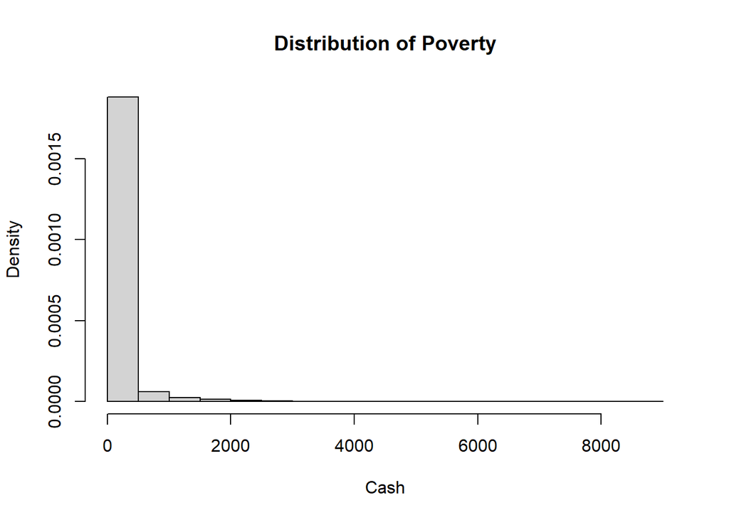

```r
poverty <- read.csv("poverty-1.csv")
hist(poverty$cash, freq = FALSE, xlab = "Cash", main = "Distribution of Poverty")
```

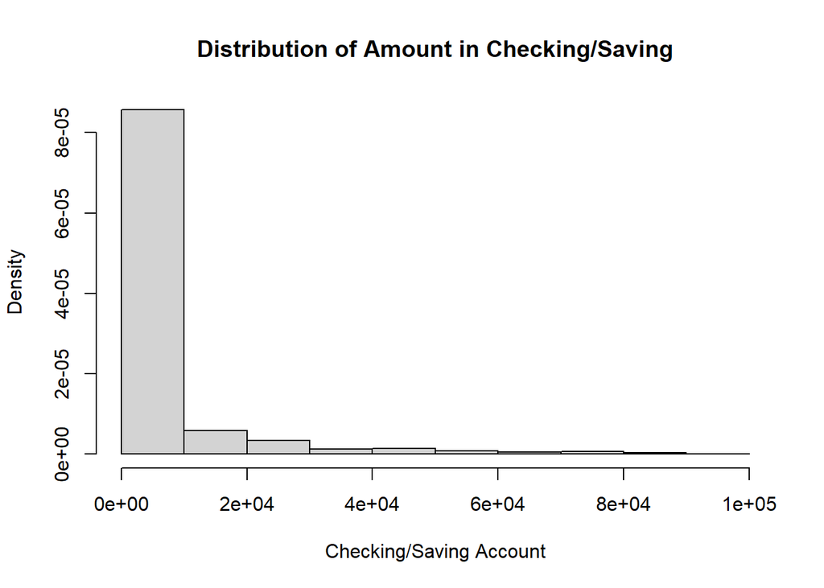

```r
hist(poverty$accts_amt, freq= FALSE, xlab = "Checking/Saving Account", main = "Distribution of Amount in Checking/Saving")
```

```r
("The distribution of both variables is skewed and contains extreme outliers that will bais the mean. Mean is not as useful")
```

```
## [1] "The distribution of both variables is skewed and contains extreme outliers that will bais the mean. Mean is not as useful"
```

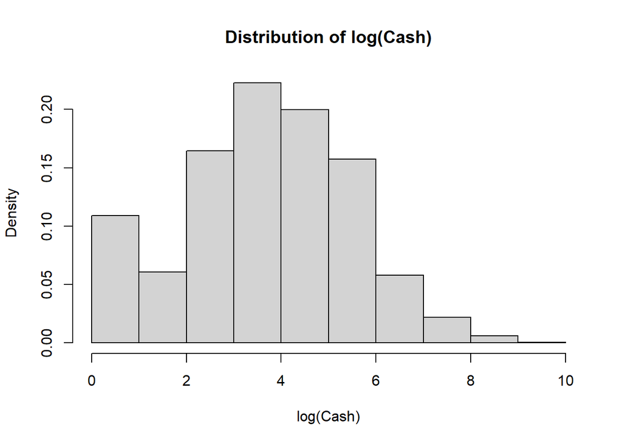

```r
poverty$log_cash <- poverty$cash
poverty$log_cash[poverty$log_cash == 0] <- 1
poverty$log_cash <- log(poverty$log_cash)

poverty$log_accts_amt <- poverty$accts_amt
poverty$log_accts_amt[poverty$log_accts_amt == 0] <- 1
poverty$log_accts_amt <- log(poverty$log_accts_amt)

hist(poverty$log_cash, freq = FALSE, xlab = "log(Cash)", main = "Distribution of log(Cash)")
```

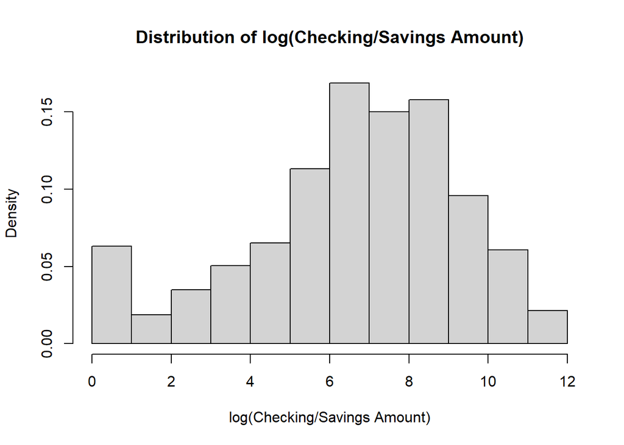

```r
hist(poverty$log_accts_amt, freq = FALSE, xlab = "log(Checking/Savings Amount)", main = "Distribution of log(Checking/Savings Amount)")
```

```r
("Advantage: The distribution is much cleaner and eliminated the extreme outliers. Disadvantage: log scale makes understanding the values more difficult")
```

```
## [1] "Advantage: The distribution is much cleaner and eliminated the extreme outliers. Disadvantage: log scale makes understanding the values more difficult"
```

## Question 2

Now, let’s examine the primary outcome of interest for this study– the effect of a change in financial situation (in this case, getting paid on payday) on economic decision-making and cognitive performance. Begin by calculating the treatment effect for the `stroop_time` variable (a log-transformed variable of the average response time for the stroop cognitive test), using first the mean and then the median. What does this tell you about differences in the outcome across the two experimental conditions?

Secondly, let’s look at the relationship between finanical circumstances and the cognitive test variable. Produce two scatter plots side by side (hint: use the par(mfrow)) before your plot commands to place graphs side-by-side), one for each of the two experimental conditions, showing the bivariate relationship between your *log-transformed* `cash` variable and the amount of time it took subjects to complete the stroop cognitive test administered in the survey (`stroop_time`). Place the `stroop_time` variable on the y-axis. Be sure to title your graphs to differentiate between the `Before Payday` and `After Payday` conditions. Now do the same, for the *log-transformed* `accts_amt` variable.

Briefly comment on your results in light of the hypothesis that changes in economic circumstances will influence cognitive performance.

## Answer 2

```r
mean(poverty$stroop_time[poverty$treatment == "After Payday"]) - mean(poverty$stroop_time[poverty$treatment == "Before Payday"])
```

```
## [1] 0.01142325
```

```r
median(poverty$stroop_time[poverty$treatment == "After Payday"]) - median(poverty$stroop_time[poverty$treatment == "Before Payday"])
```

```
## [1] 0.01430528
```

```r
("The median and mean had similar results and are close to 0. So it means there is not much variation")
```

```
## [1] "The median and mean had similar results and are close to 0. So it means there is not much variation"
```

```r
par(mrfrow = c(1, 2))
```

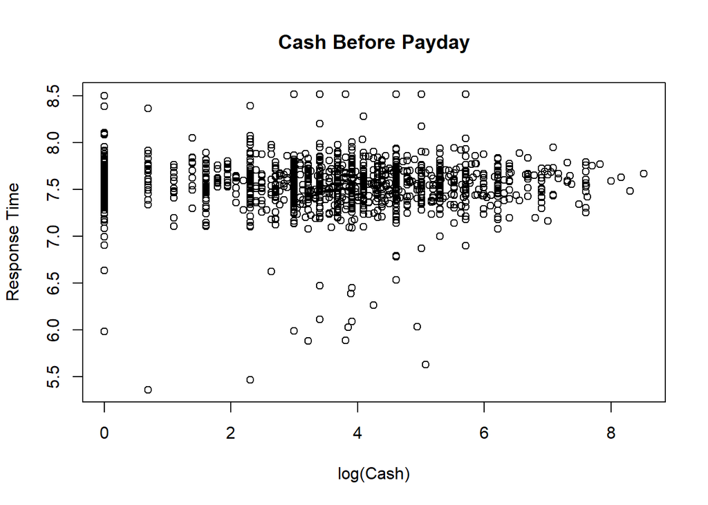

```r
plot(poverty$log_cash[poverty$treatment == "Before Payday"], poverty$stroop_time[poverty$treatment == "Before Payday"], ylab = "Response Time", xlab = "log(Cash)", main = "Cash Before Payday")
```

[figure not shown]

```r
plot(poverty$log_cash[poverty$treatment == "After Payday"], poverty$stroop_time[poverty$treatment == "After Payday"], ylab = "Response Time", xlab = "log(Amount Checking/Savings", main = "Cash After Payday")
```

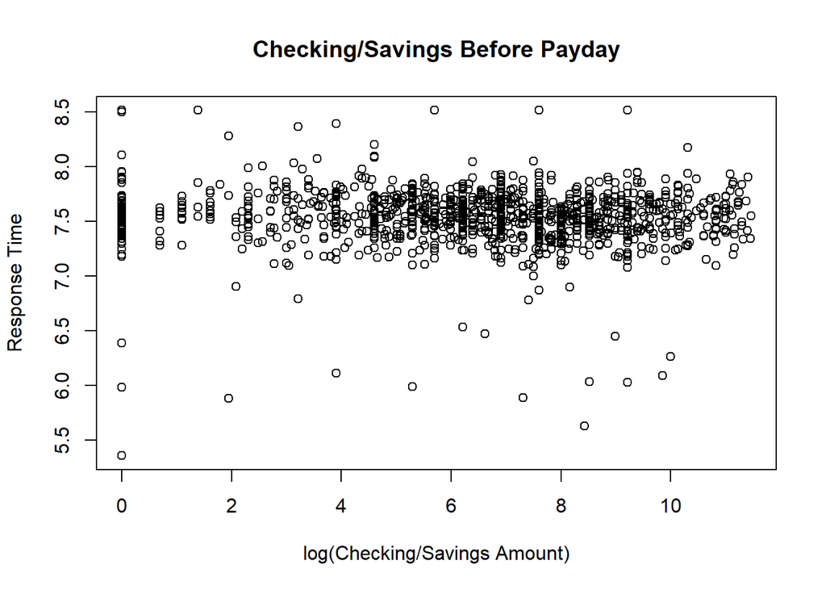

```r
plot(poverty$log_accts_amt[poverty$treatment == "Before Payday"], poverty$stroop_time[poverty$treatment == "Before Payday"], ylab = "Response Time", xlab = "log(Checking/Savings Amount)", main = "Checking/Savings Before Payday")
```

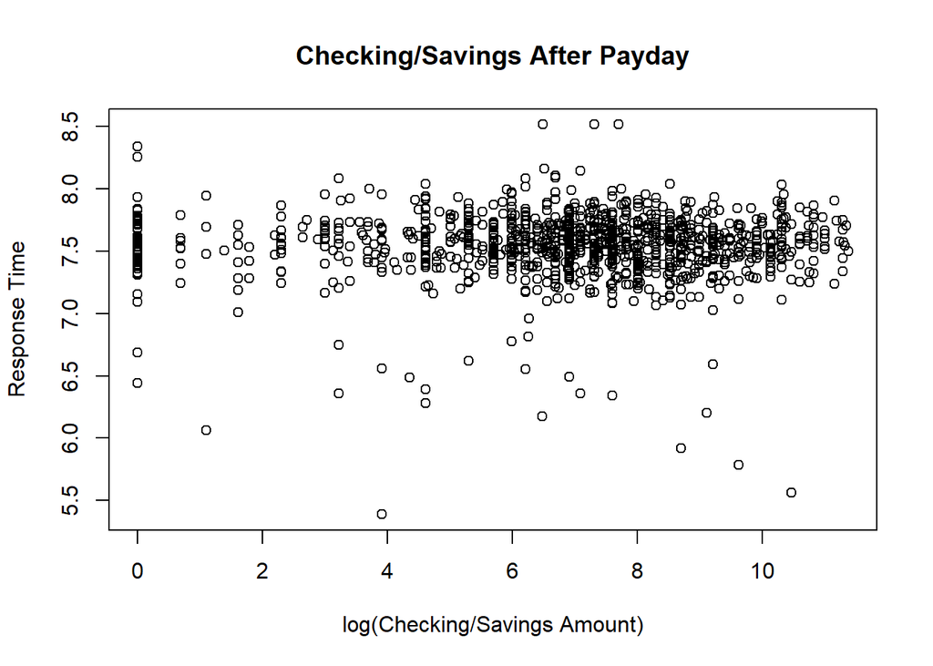

```r
plot(poverty$log_accts_amt[poverty$treatment == "After Payday"], poverty$stroop_time[poverty$treatment == "After Payday"], ylab = "Response Time", xlab = "log(Checking/Savings Amount)", main = "Checking/Savings After Payday")
```

```r
("There is no change of the response time before and after payday. This shows that the hypothesis is incorrect and that economic circumstances don't effect time")
```

```
## [1] "There is no change of the response time before and after payday. This shows that the hypothesis is incorrect and that economic circumstances don't effect time"
```

## Question 3

Now, let’s take a closer look at whether or not the `Before Payday` versus `After Payday` treatment created measurable differences in financial circumstances. What is the effect of payday on participants’ financial resources? To help with interpretability, use the original variables `cash` and `accts_amt` to calculate this effect. Calculate both the mean and median effect. Does the measure of central tendency you use affect your perception of the effect?

## Answer 3

```r
meancashdiff <- mean(poverty$cash[poverty$treatment == "After Payday"], na.rm = TRUE) - mean(poverty$cash[poverty$treatment == "Before Payday"], na.rm = TRUE)

mediancashdiff <- median(poverty$cash[poverty$treatment == "After Payday"], na.rm = TRUE) - median(poverty$cash[poverty$treatment == "Before Payday"], na.rm = TRUE)

meancashdiff
```

```
## [1] 36.77511
```

```r
mediancashdiff
```

```
## [1] 10
```

```r
("After payday, respondents have more cash in hand than before payday respondents. The reason why the two are different is because the mean is more sensitive to outliers and why there is a difference")
```

```
## [1] "After payday, respondents have more cash in hand than before payday respondents. The reason why the two are different is because the mean is more sensitive to outliers and why there is a difference"
```

```r
amount.mean.diff <- mean(poverty$accts_amt[poverty$treatment == "After Payday"], na.rm = TRUE) -
  mean(poverty$accts_amt[poverty$treatment == "Before Payday"], na.rm = TRUE)
amount.med.diff <- median(poverty$accts_amt[poverty$treatment == "After Payday"], na.rm = TRUE) -
  median(poverty$accts_amt[poverty$treatment == "Before Payday"], na.rm = TRUE)

amount.mean.diff
```

```
## [1] -251.9087
```

```r
amount.med.diff
```

```
## [1] 450
```

```r
("the mean shows that there is less money in saving/checking accounts after payday which makes no sense. The median shows an increase in the amount in saving/checking accounts, which makes sense. The large gap is explained by the outliers that caused the distribution to be uneven")
```

```
## [1] "the mean shows that there is less money in saving/checking accounts after payday which makes no sense. The median shows an increase in the amount in saving/checking accounts, which makes sense. The large gap is explained by the outliers that caused the distribution to be uneven"
```

## Question 4

Compare the distributions of the `Before Payday` and `After Payday` groups for the *log-transformed* `cash` and `accts_amt` variables. Use quantile-quantile plots to do this comparison, and add a 45-degree line in a color of your choice (not black). Briefly interpret your results and their implications for the authors’ argument that their study generated variation in financial resources before and after payday. When appropriate, state which ranges of the outcome variables you would focus on when comparing decision-making and cognitive capacity across these two treatment conditions.

## Answer 4

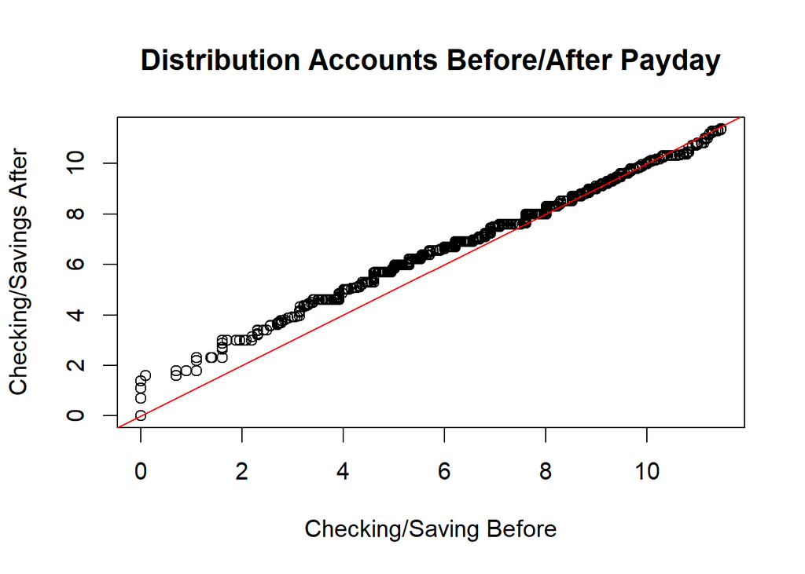

```r
par(cex = 1.25)
qqplot(poverty$log_accts_amt[poverty$treatment == "Before Payday"],poverty$log_accts_amt[poverty$treatment == "After Payday"], xlab = "Checking/Saving Before", ylab = "Checking/Savings After", main = "Distribution Accounts Before/After Payday")
abline(0, 1, col = "red")
```

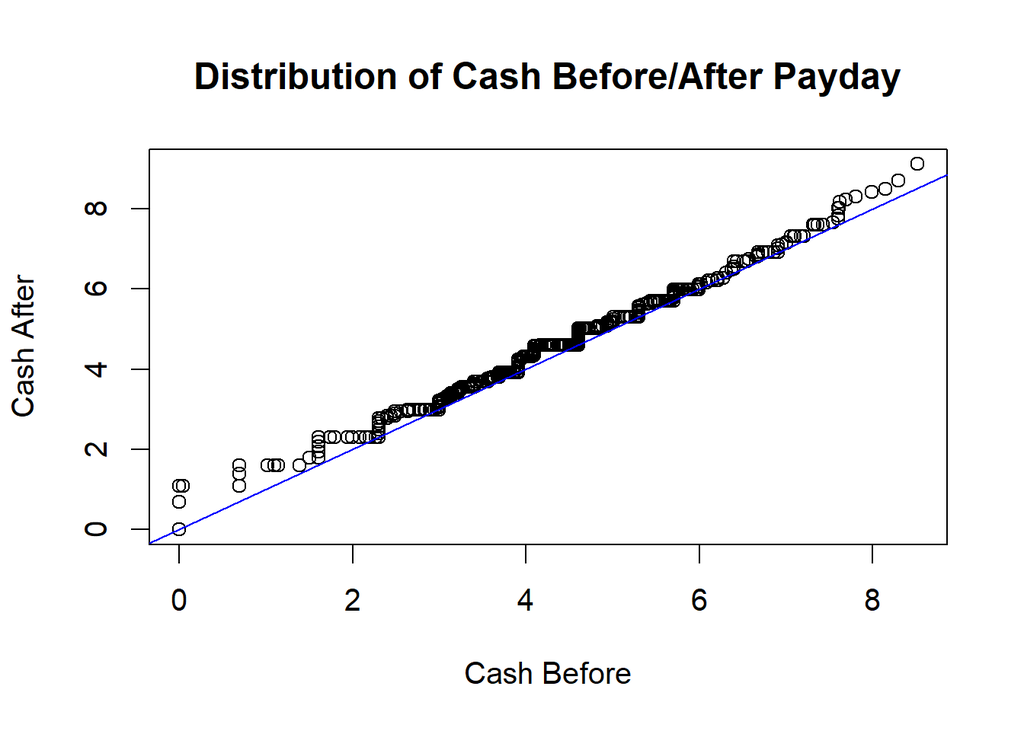

```r
qqplot(poverty$log_cash[poverty$treatment == "Before Payday"],poverty$log_cash[poverty$treatment == "After Payday"], xlab = "Cash Before", ylab = "Cash After", main = "Distribution of Cash Before/After Payday")
abline(0, 1, col = "blue")
```

```r
("While after payday respondents on the low end of the log account balance distribution seem to have more money in checking and savings accounts than those before payday, the high end of the respective respondent distributions look relatively similar to one another. I would focus more on the Checking/Savings amount which almost shows that the higher the paycheck the more was already in savings (for distribution of check/savings). More specifically at the median point")
```

[output not shown]

## Question 5

In class, we covered the difference-in-difference design for comparing average treatment effects across treatment and control groups. This design can also be used to compare average treatment effects across different ranges of a *pre-treatment variable*- a variable that asks about people’s circumstances before the treatment and thus could not be affected by the treatment. This is known as *heterogeneous treatment effects* – the idea that the treatment may have differential effects for different subpopulations. Let’s look at the pre-treatment variable `income_less20k`. Calculate the treatment effect of Payday on amount in checking and savings accounts separately for respondents earning more than 20,000 dollars a year and those earning less than 20,000 dollars. Use the original `accts_amt` variable for this calculation. Then take the difference between the effects you calculate. What does this comparison tell you about how payday affects the amount that people have in their accounts? Are you convinced by the authors’ main finding from Question 2 in light of your investigation of their success in manipulating cash and account balances before and after payday?